# How to explore correlations?

[Source](https://drsimonj.svbtle.com/exploring-correlations-in-r-with-corrr)

```r
d <- mtcars
d$hp[3] <- NA
head(d)
```

|  | mpg | cyl | disp | hp | drat | wt | qsec | vs | am | gear | carb |
| --- | --- | --- | --- | --- | --- | --- | --- | --- | --- | --- | --- |
| Mazda RX4 | 21.0 | 6 | 160 | 110 | 3.90 | 2.620 | 16.46 | 0 | 1 | 4 | 4 |
| Mazda RX4 Wag | 21.0 | 6 | 160 | 110 | 3.90 | 2.875 | 17.02 | 0 | 1 | 4 | 4 |
| Datsun 710 | 22.8 | 4 | 108 | NA | 3.85 | 2.320 | 18.61 | 1 | 1 | 4 | 1 |
| Hornet 4 Drive | 21.4 | 6 | 258 | 110 | 3.08 | 3.215 | 19.44 | 1 | 0 | 3 | 1 |
| Hornet Sportabout | 18.7 | 8 | 360 | 175 | 3.15 | 3.440 | 17.02 | 0 | 0 | 3 | 2 |
| Valiant | 18.1 | 6 | 225 | 105 | 2.76 | 3.460 | 20.22 | 1 | 0 | 3 | 1 |

We could be motivated by multicollinearity:

```r
fit_1 <- lm(mpg ~ hp,        data = d)
fit_2 <- lm(mpg ~ hp + disp, data = d)
```

```r
summary(fit_1)
```

```
##
## Call:
## lm(formula = mpg ~ hp, data = d)
##
## Residuals:
##     Min      1Q  Median      3Q     Max
## -5.7219 -2.2887 -0.8677  1.5815  8.1743
##
## Coefficients:
##             Estimate Std. Error t value Pr(>|t|)
## (Intercept) 30.18457    1.69527  17.805  < 2e-16 ***
## hp          -0.06860    0.01039  -6.604 3.08e-07 ***
## ---
## Signif. codes:  0 '***' 0.001 '**' 0.01 '*' 0.05 '.' 0.1 ' ' 1
##
## Residual standard error: 3.925 on 29 degrees of freedom
##   (1 observation deleted due to missingness)
## Multiple R-squared:  0.6006, Adjusted R-squared:  0.5868
## F-statistic: 43.61 on 1 and 29 DF,  p-value: 3.085e-07
```

```r
summary(fit_2)
```

```
##
## Call:
## lm(formula = mpg ~ hp + disp, data = d)
##
## Residuals:
##     Min      1Q  Median      3Q     Max
## -4.9136 -2.3472 -0.7302  1.9798  6.7549
##
## Coefficients:
##              Estimate Std. Error t value Pr(>|t|)
## (Intercept) 30.963202   1.373067  22.550  < 2e-16 ***
## hp          -0.024840   0.013480  -1.843 0.075991 .
## disp        -0.030992   0.007504  -4.130 0.000296 ***
## ---
## Signif. codes:  0 '***' 0.001 '**' 0.01 '*' 0.05 '.' 0.1 ' ' 1
##
## Residual standard error: 3.149 on 28 degrees of freedom
##   (1 observation deleted due to missingness)
## Multiple R-squared:  0.7518, Adjusted R-squared:  0.7341
## F-statistic: 42.41 on 2 and 28 DF,  p-value: 3.368e-09
```

Strange result. Let’s check the correlations between `mpg`, `hp`, and `disp` to try and diagnose this problem. It should be simple using the base R function, `cor()`. Right?

Err, what is with all the `NA`‘s ?

```r
rs <- cor(d)
rs
```

```
##             mpg        cyl       disp hp        drat         wt
## mpg   1.0000000 -0.8521620 -0.8475514 NA  0.68117191 -0.8676594
## cyl  -0.8521620  1.0000000  0.9020329 NA -0.69993811  0.7824958
## disp -0.8475514  0.9020329  1.0000000 NA -0.71021393  0.8879799
## hp           NA         NA         NA  1          NA         NA
## drat  0.6811719 -0.6999381 -0.7102139 NA  1.00000000 -0.7124406
## wt   -0.8676594  0.7824958  0.8879799 NA -0.71244065  1.0000000
## qsec  0.4186840 -0.5912421 -0.4336979 NA  0.09120476 -0.1747159
## vs    0.6640389 -0.8108118 -0.7104159 NA  0.44027846 -0.5549157
## am    0.5998324 -0.5226070 -0.5912270 NA  0.71271113 -0.6924953
## gear  0.4802848 -0.4926866 -0.5555692 NA  0.69961013 -0.5832870
## carb -0.5509251  0.5269883  0.3949769 NA -0.09078980  0.4276059
##             qsec         vs          am       gear        carb
## mpg   0.41868403  0.6640389  0.59983243  0.4802848 -0.55092507
## cyl  -0.59124207 -0.8108118 -0.52260705 -0.4926866  0.52698829
## disp -0.43369788 -0.7104159 -0.59122704 -0.5555692  0.39497686
## hp            NA         NA          NA         NA          NA
## drat  0.09120476  0.4402785  0.71271113  0.6996101 -0.09078980
## wt   -0.17471588 -0.5549157 -0.69249526 -0.5832870  0.42760594
## qsec  1.00000000  0.7445354 -0.22986086 -0.2126822 -0.65624923
## vs    0.74453544  1.0000000  0.16834512  0.2060233 -0.56960714
## am   -0.22986086  0.1683451  1.00000000  0.7940588  0.05753435
## gear -0.21268223  0.2060233  0.79405876  1.0000000  0.27407284
## carb -0.65624923 -0.5696071  0.05753435  0.2740728  1.00000000
```

Have to handle missing values with `use`:

```r
rs <- cor(d, use = "pairwise.complete.obs")
rs
```

```
##             mpg        cyl       disp         hp        drat         wt
## mpg   1.0000000 -0.8521620 -0.8475514 -0.7749843  0.68117191 -0.8676594
## cyl  -0.8521620  1.0000000  0.9020329  0.8298025 -0.69993811  0.7824958
## disp -0.8475514  0.9020329  1.0000000  0.7860001 -0.71021393  0.8879799
## hp   -0.7749843  0.8298025  0.7860001  1.0000000 -0.44258306  0.6505927
## drat  0.6811719 -0.6999381 -0.7102139 -0.4425831  1.00000000 -0.7124406
## wt   -0.8676594  0.7824958  0.8879799  0.6505927 -0.71244065  1.0000000
## qsec  0.4186840 -0.5912421 -0.4336979 -0.7064809  0.09120476 -0.1747159
## vs    0.6640389 -0.8108118 -0.7104159 -0.7162015  0.44027846 -0.5549157
## am    0.5998324 -0.5226070 -0.5912270 -0.2196179  0.71271113 -0.6924953
## gear  0.4802848 -0.4926866 -0.5555692 -0.1161968  0.69961013 -0.5832870
## carb -0.5509251  0.5269883  0.3949769  0.7437843 -0.09078980  0.4276059
##             qsec         vs          am       gear        carb
## mpg   0.41868403  0.6640389  0.59983243  0.4802848 -0.55092507
## cyl  -0.59124207 -0.8108118 -0.52260705 -0.4926866  0.52698829
## disp -0.43369788 -0.7104159 -0.59122704 -0.5555692  0.39497686
## hp   -0.70648093 -0.7162015 -0.21961793 -0.1161968  0.74378428
## drat  0.09120476  0.4402785  0.71271113  0.6996101 -0.09078980
## wt   -0.17471588 -0.5549157 -0.69249526 -0.5832870  0.42760594
## qsec  1.00000000  0.7445354 -0.22986086 -0.2126822 -0.65624923
## vs    0.74453544  1.0000000  0.16834512  0.2060233 -0.56960714
## am   -0.22986086  0.1683451  1.00000000  0.7940588  0.05753435
## gear -0.21268223  0.2060233  0.79405876  1.0000000  0.27407284
## carb -0.65624923 -0.5696071  0.05753435  0.2740728  1.00000000
```

Can we focus on subset with dplyr? Nope.

```r
#dplyr::select(rs, mpg, hp, disp)
```

Riiiiiight! It’s a matrix and dplyr is for data frames.

```r
class(rs)
```

```
## [1] "matrix"
```

So we can use square brackets with matrices? Or not…

```r
vars <- c("mpg", "hp", "disp")
rs[rownames(rs) %in% vars]
```

```
##  [1]  1.0000000 -0.8475514 -0.7749843 -0.8521620  0.9020329  0.8298025
##  [7] -0.8475514  1.0000000  0.7860001 -0.7749843  0.7860001  1.0000000
## [13]  0.6811719 -0.7102139 -0.4425831 -0.8676594  0.8879799  0.6505927
## [19]  0.4186840 -0.4336979 -0.7064809  0.6640389 -0.7104159 -0.7162015
## [25]  0.5998324 -0.5912270 -0.2196179  0.4802848 -0.5555692 -0.1161968
## [31] -0.5509251  0.3949769  0.7437843
```

Mm, square brackets can take on different functions with matrices. Without a comma, it’s treated like a vector. With a comma, we can separately specify the dimensions.

```r
vars <- c("mpg", "hp", "disp")
rs[rownames(rs) %in% vars, colnames(rs) %in% vars]
```

```
##             mpg       disp         hp
## mpg   1.0000000 -0.8475514 -0.7749843
## disp -0.8475514  1.0000000  0.7860001
## hp   -0.7749843  0.7860001  1.0000000
```

We diagnosed our multicollinearity problem. What if we want to something a bit more complex like exploring clustering of variables in high dimensional space? Could use exploratory factor analysis.

```r
factanal(na.omit(d), factors = 2)
```

```
##
## Call:
## factanal(x = na.omit(d), factors = 2)
##
## Uniquenesses:
##   mpg   cyl  disp    hp  drat    wt  qsec    vs    am  gear  carb
## 0.155 0.072 0.101 0.145 0.295 0.174 0.154 0.264 0.160 0.245 0.387
##
## Loadings:
##      Factor1 Factor2
## mpg   0.694  -0.603
## cyl  -0.629   0.729
## disp -0.730   0.605
## hp   -0.335   0.862
## drat  0.810  -0.221
## wt   -0.809   0.414
## qsec -0.162  -0.905
## vs    0.280  -0.811
## am    0.910   0.110
## gear  0.859   0.133
## carb          0.781
##
##                Factor1 Factor2
## SS loadings      4.506   4.342
## Proportion Var   0.410   0.395
## Cumulative Var   0.410   0.804
##
## Test of the hypothesis that 2 factors are sufficient.
## The chi square statistic is 68.49 on 34 degrees of freedom.
## The p-value is 0.000414
```

```r
factanal(na.omit(d), factors = 5)
```

```
##
## Call:
## factanal(x = na.omit(d), factors = 5)
##
## Uniquenesses:
##   mpg   cyl  disp    hp  drat    wt  qsec    vs    am  gear  carb
## 0.112 0.044 0.012 0.066 0.275 0.005 0.091 0.128 0.136 0.143 0.045
##
## Loadings:
##      Factor1 Factor2 Factor3 Factor4 Factor5
## mpg   0.647  -0.441  -0.483  -0.203
## cyl  -0.604   0.694   0.293   0.128
## disp -0.645   0.543   0.202   0.451   0.182
## hp   -0.264   0.659   0.544   0.205   0.305
## drat  0.806  -0.250
## wt   -0.725   0.226   0.420   0.488
## qsec -0.184  -0.890  -0.269
## vs    0.242  -0.848  -0.209  -0.155   0.163
## am    0.916   0.118
## gear  0.892           0.237
## carb  0.119   0.458   0.853
##
##                Factor1 Factor2 Factor3 Factor4 Factor5
## SS loadings      4.186   3.255   1.739   0.582   0.180
## Proportion Var   0.381   0.296   0.158   0.053   0.016
## Cumulative Var   0.381   0.676   0.835   0.887   0.904
##
## Test of the hypothesis that 5 factors are sufficient.
## The chi square statistic is 2.17 on 10 degrees of freedom.
## The p-value is 0.995
```

So many questions! I’d much rather explore the correlations.

Let’s try to find all variables with a correlation greater than 0.90. Why doesn’t this work?!

```r
col_has_over_90 <- apply(rs, 2, function(x) any(x > .9))
rs[, col_has_over_90]
```

```
##             mpg        cyl       disp         hp        drat         wt
## mpg   1.0000000 -0.8521620 -0.8475514 -0.7749843  0.68117191 -0.8676594
## cyl  -0.8521620  1.0000000  0.9020329  0.8298025 -0.69993811  0.7824958
## disp -0.8475514  0.9020329  1.0000000  0.7860001 -0.71021393  0.8879799
## hp   -0.7749843  0.8298025  0.7860001  1.0000000 -0.44258306  0.6505927
## drat  0.6811719 -0.6999381 -0.7102139 -0.4425831  1.00000000 -0.7124406
## wt   -0.8676594  0.7824958  0.8879799  0.6505927 -0.71244065  1.0000000
## qsec  0.4186840 -0.5912421 -0.4336979 -0.7064809  0.09120476 -0.1747159
## vs    0.6640389 -0.8108118 -0.7104159 -0.7162015  0.44027846 -0.5549157
## am    0.5998324 -0.5226070 -0.5912270 -0.2196179  0.71271113 -0.6924953
## gear  0.4802848 -0.4926866 -0.5555692 -0.1161968  0.69961013 -0.5832870
## carb -0.5509251  0.5269883  0.3949769  0.7437843 -0.09078980  0.4276059
##             qsec         vs          am       gear        carb
## mpg   0.41868403  0.6640389  0.59983243  0.4802848 -0.55092507
## cyl  -0.59124207 -0.8108118 -0.52260705 -0.4926866  0.52698829
## disp -0.43369788 -0.7104159 -0.59122704 -0.5555692  0.39497686
## hp   -0.70648093 -0.7162015 -0.21961793 -0.1161968  0.74378428
## drat  0.09120476  0.4402785  0.71271113  0.6996101 -0.09078980
## wt   -0.17471588 -0.5549157 -0.69249526 -0.5832870  0.42760594
## qsec  1.00000000  0.7445354 -0.22986086 -0.2126822 -0.65624923
## vs    0.74453544  1.0000000  0.16834512  0.2060233 -0.56960714
## am   -0.22986086  0.1683451  1.00000000  0.7940588  0.05753435
## gear -0.21268223  0.2060233  0.79405876  1.0000000  0.27407284
## carb -0.65624923 -0.5696071  0.05753435  0.2740728  1.00000000
```

The diagonal is 1. All cols have a value greater than .90!

Exclude diagonal:

```r
diag(rs) <- NA
col_has_over_90 <- apply(rs, 2, function(x) any(x > .9, na.rm = TRUE))
rs[, col_has_over_90]
```

```
##             cyl       disp
## mpg  -0.8521620 -0.8475514
## cyl          NA  0.9020329
## disp  0.9020329         NA
## hp    0.8298025  0.7860001
## drat -0.6999381 -0.7102139
## wt    0.7824958  0.8879799
## qsec -0.5912421 -0.4336979
## vs   -0.8108118 -0.7104159
## am   -0.5226070 -0.5912270
## gear -0.4926866 -0.5555692
## carb  0.5269883  0.3949769
```

## Exploring data with the tidyverse

```r
library(tidyverse)
```

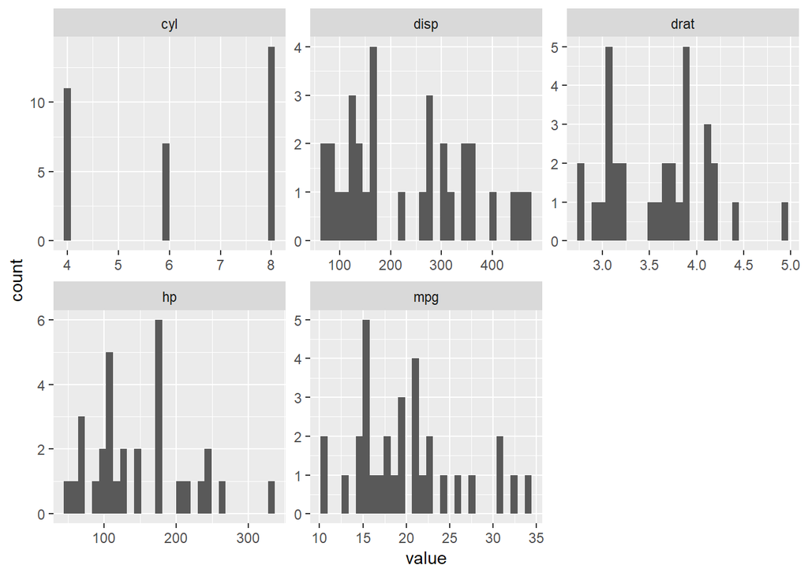

```r
d %>%
  select(mpg:drat) %>%
  gather() %>%
  ggplot(aes(value)) +
    geom_histogram() +
    facet_wrap(~key, scales = "free")
```

# Using `corr`

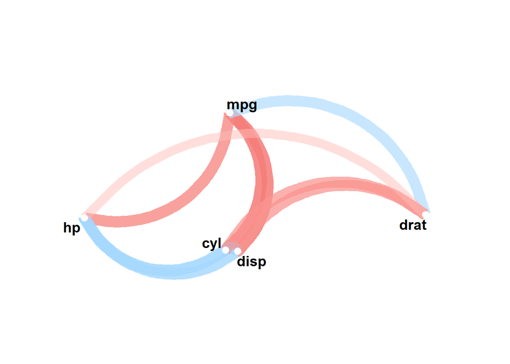

```r
library(corrr)
d %>%
  correlate() %>%
  focus(mpg:drat, mirror = TRUE) %>%
  network_plot()
```

```r
rs <- correlate(d)
rs
```

| rowname | mpg | cyl | disp | hp | drat | wt | qsec | vs | am | gear | carb |
| --- | --- | --- | --- | --- | --- | --- | --- | --- | --- | --- | --- |
| mpg | NA | -0.8521620 | -0.8475514 | -0.7749843 | 0.68117191 | -0.8676594 | 0.41868403 | 0.6640389 | 0.59983243 | 0.4802848 | -0.55092507 |
| cyl | -0.8521620 | NA | 0.9020329 | 0.8298025 | -0.69993811 | 0.7824958 | -0.59124207 | -0.8108118 | -0.52260705 | -0.4926866 | 0.52698829 |
| disp | -0.8475514 | 0.9020329 | NA | 0.7860001 | -0.71021393 | 0.8879799 | -0.43369788 | -0.7104159 | -0.59122704 | -0.5555692 | 0.39497686 |
| hp | -0.7749843 | 0.8298025 | 0.7860001 | NA | -0.44258306 | 0.6505927 | -0.70648093 | -0.7162015 | -0.21961793 | -0.1161968 | 0.74378428 |
| drat | 0.6811719 | -0.6999381 | -0.7102139 | -0.4425831 | NA | -0.7124406 | 0.09120476 | 0.4402785 | 0.71271113 | 0.6996101 | -0.09078980 |
| wt | -0.8676594 | 0.7824958 | 0.8879799 | 0.6505927 | -0.71244065 | NA | -0.17471588 | -0.5549157 | -0.69249526 | -0.5832870 | 0.42760594 |
| qsec | 0.4186840 | -0.5912421 | -0.4336979 | -0.7064809 | 0.09120476 | -0.1747159 | NA | 0.7445354 | -0.22986086 | -0.2126822 | -0.65624923 |
| vs | 0.6640389 | -0.8108118 | -0.7104159 | -0.7162015 | 0.44027846 | -0.5549157 | 0.74453544 | NA | 0.16834512 | 0.2060233 | -0.56960714 |
| am | 0.5998324 | -0.5226070 | -0.5912270 | -0.2196179 | 0.71271113 | -0.6924953 | -0.22986086 | 0.1683451 | NA | 0.7940588 | 0.05753435 |
| gear | 0.4802848 | -0.4926866 | -0.5555692 | -0.1161968 | 0.69961013 | -0.5832870 | -0.21268223 | 0.2060233 | 0.79405876 | NA | 0.27407284 |

[output cut: 1 more lines]

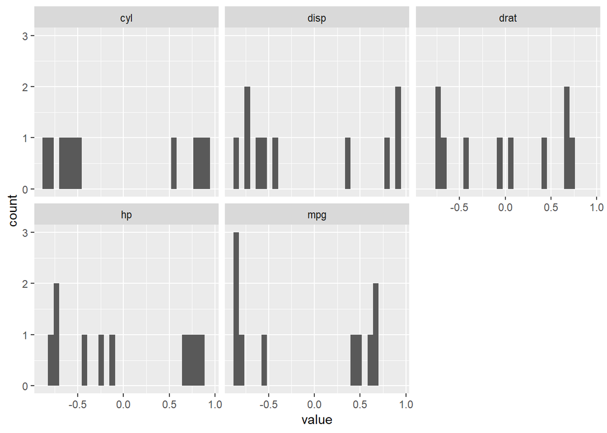

```r
rs %>%
  select(mpg:drat) %>%
  gather() %>%
  ggplot(aes(value)) +
    geom_histogram() +
    facet_wrap(~key)
```

How about that challenge to find cols with a correlation greater than .9?

```r
any_over_90 <- function(x) any(x > .9, na.rm = TRUE)
rs %>% select_if(any_over_90)
```

| rowname | cyl | disp |
| --- | --- | --- |
| mpg | -0.8521620 | -0.8475514 |
| cyl | NA | 0.9020329 |
| disp | 0.9020329 | NA |
| hp | 0.8298025 | 0.7860001 |
| drat | -0.6999381 | -0.7102139 |
| wt | 0.7824958 | 0.8879799 |
| qsec | -0.5912421 | -0.4336979 |
| vs | -0.8108118 | -0.7104159 |
| am | -0.5226070 | -0.5912270 |
| gear | -0.4926866 | -0.5555692 |

[output cut: 1 more lines]

```r
rs %>%
  focus(mpg, disp, hp)
```

| rowname | mpg | disp | hp |
| --- | --- | --- | --- |
| cyl | -0.8521620 | 0.9020329 | 0.8298025 |
| drat | 0.6811719 | -0.7102139 | -0.4425831 |
| wt | -0.8676594 | 0.8879799 | 0.6505927 |
| qsec | 0.4186840 | -0.4336979 | -0.7064809 |
| vs | 0.6640389 | -0.7104159 | -0.7162015 |
| am | 0.5998324 | -0.5912270 | -0.2196179 |
| gear | 0.4802848 | -0.5555692 | -0.1161968 |
| carb | -0.5509251 | 0.3949769 | 0.7437843 |

```r
rs %>%
  focus(-mpg, -disp, -hp)
```

| rowname | cyl | drat | wt | qsec | vs | am | gear | carb |
| --- | --- | --- | --- | --- | --- | --- | --- | --- |
| mpg | -0.8521620 | 0.6811719 | -0.8676594 | 0.4186840 | 0.6640389 | 0.5998324 | 0.4802848 | -0.5509251 |
| disp | 0.9020329 | -0.7102139 | 0.8879799 | -0.4336979 | -0.7104159 | -0.5912270 | -0.5555692 | 0.3949769 |
| hp | 0.8298025 | -0.4425831 | 0.6505927 | -0.7064809 | -0.7162015 | -0.2196179 | -0.1161968 | 0.7437843 |

```r
rs %>%
  focus(mpg, disp, hp, mirror = TRUE)
```

| rowname | mpg | disp | hp |
| --- | --- | --- | --- |
| mpg | NA | -0.8475514 | -0.7749843 |
| disp | -0.8475514 | NA | 0.7860001 |
| hp | -0.7749843 | 0.7860001 | NA |

```r
rs %>%
  focus(matches("^d"))
```

| rowname | disp | drat |
| --- | --- | --- |
| mpg | -0.8475514 | 0.68117191 |
| cyl | 0.9020329 | -0.69993811 |
| hp | 0.7860001 | -0.44258306 |
| wt | 0.8879799 | -0.71244065 |
| qsec | -0.4336979 | 0.09120476 |
| vs | -0.7104159 | 0.44027846 |
| am | -0.5912270 | 0.71271113 |
| gear | -0.5555692 | 0.69961013 |
| carb | 0.3949769 | -0.09078980 |

```r
rs %>%
  focus(mpg)
```

| rowname | mpg |
| --- | --- |
| cyl | -0.8521620 |
| disp | -0.8475514 |
| hp | -0.7749843 |
| drat | 0.6811719 |
| wt | -0.8676594 |
| qsec | 0.4186840 |
| vs | 0.6640389 |
| am | 0.5998324 |
| gear | 0.4802848 |
| carb | -0.5509251 |

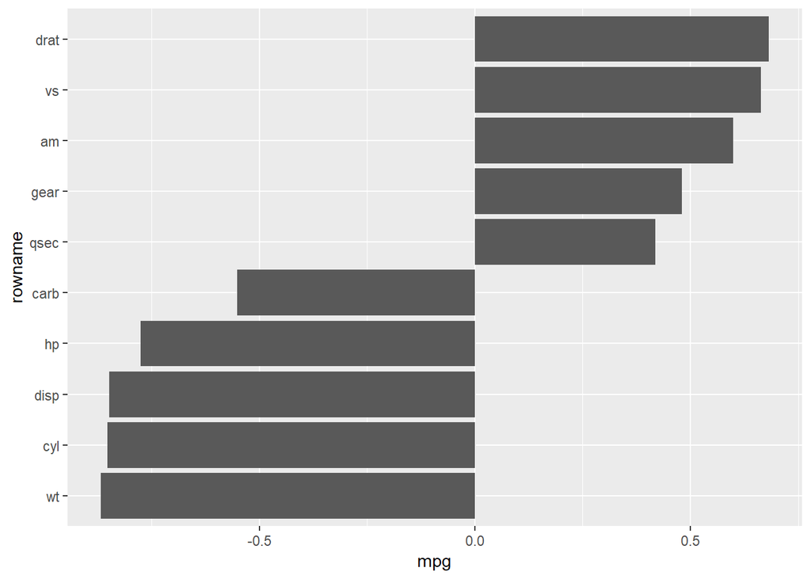

```r
rs %>%
  focus(mpg) %>%
  mutate(rowname = reorder(rowname, mpg)) %>%
  ggplot(aes(rowname, mpg)) +
    geom_col() + coord_flip()
```

```r
rs %>% rearrange()
```

| rowname | am | gear | drat | wt | disp | mpg | cyl | vs | hp | carb | qsec |
| --- | --- | --- | --- | --- | --- | --- | --- | --- | --- | --- | --- |
| am | NA | 0.7940588 | 0.71271113 | -0.6924953 | -0.5912270 | 0.5998324 | -0.5226070 | 0.1683451 | -0.2196179 | 0.05753435 | -0.22986086 |
| gear | 0.79405876 | NA | 0.69961013 | -0.5832870 | -0.5555692 | 0.4802848 | -0.4926866 | 0.2060233 | -0.1161968 | 0.27407284 | -0.21268223 |
| drat | 0.71271113 | 0.6996101 | NA | -0.7124406 | -0.7102139 | 0.6811719 | -0.6999381 | 0.4402785 | -0.4425831 | -0.09078980 | 0.09120476 |
| wt | -0.69249526 | -0.5832870 | -0.71244065 | NA | 0.8879799 | -0.8676594 | 0.7824958 | -0.5549157 | 0.6505927 | 0.42760594 | -0.17471588 |
| disp | -0.59122704 | -0.5555692 | -0.71021393 | 0.8879799 | NA | -0.8475514 | 0.9020329 | -0.7104159 | 0.7860001 | 0.39497686 | -0.43369788 |
| mpg | 0.59983243 | 0.4802848 | 0.68117191 | -0.8676594 | -0.8475514 | NA | -0.8521620 | 0.6640389 | -0.7749843 | -0.55092507 | 0.41868403 |
| cyl | -0.52260705 | -0.4926866 | -0.69993811 | 0.7824958 | 0.9020329 | -0.8521620 | NA | -0.8108118 | 0.8298025 | 0.52698829 | -0.59124207 |
| vs | 0.16834512 | 0.2060233 | 0.44027846 | -0.5549157 | -0.7104159 | 0.6640389 | -0.8108118 | NA | -0.7162015 | -0.56960714 | 0.74453544 |
| hp | -0.21961793 | -0.1161968 | -0.44258306 | 0.6505927 | 0.7860001 | -0.7749843 | 0.8298025 | -0.7162015 | NA | 0.74378428 | -0.70648093 |
| carb | 0.05753435 | 0.2740728 | -0.09078980 | 0.4276059 | 0.3949769 | -0.5509251 | 0.5269883 | -0.5696071 | 0.7437843 | NA | -0.65624923 |

[output cut: 1 more lines]

```r
rs %>% shave()
```

| rowname | mpg | cyl | disp | hp | drat | wt | qsec | vs | am | gear | carb |
| --- | --- | --- | --- | --- | --- | --- | --- | --- | --- | --- | --- |
| mpg | NA | NA | NA | NA | NA | NA | NA | NA | NA | NA | NA |
| cyl | -0.8521620 | NA | NA | NA | NA | NA | NA | NA | NA | NA | NA |
| disp | -0.8475514 | 0.9020329 | NA | NA | NA | NA | NA | NA | NA | NA | NA |
| hp | -0.7749843 | 0.8298025 | 0.7860001 | NA | NA | NA | NA | NA | NA | NA | NA |
| drat | 0.6811719 | -0.6999381 | -0.7102139 | -0.4425831 | NA | NA | NA | NA | NA | NA | NA |
| wt | -0.8676594 | 0.7824958 | 0.8879799 | 0.6505927 | -0.71244065 | NA | NA | NA | NA | NA | NA |
| qsec | 0.4186840 | -0.5912421 | -0.4336979 | -0.7064809 | 0.09120476 | -0.1747159 | NA | NA | NA | NA | NA |
| vs | 0.6640389 | -0.8108118 | -0.7104159 | -0.7162015 | 0.44027846 | -0.5549157 | 0.7445354 | NA | NA | NA | NA |
| am | 0.5998324 | -0.5226070 | -0.5912270 | -0.2196179 | 0.71271113 | -0.6924953 | -0.2298609 | 0.1683451 | NA | NA | NA |
| gear | 0.4802848 | -0.4926866 | -0.5555692 | -0.1161968 | 0.69961013 | -0.5832870 | -0.2126822 | 0.2060233 | 0.79405876 | NA | NA |

[output cut: 1 more lines]

```r
rs %>% stretch()
```

| x | y | r |
| --- | --- | --- |
| mpg | mpg | NA |
| mpg | cyl | -0.85216196 |
| mpg | disp | -0.84755138 |
| mpg | hp | -0.77498433 |
| mpg | drat | 0.68117191 |
| mpg | wt | -0.86765938 |
| mpg | qsec | 0.41868403 |
| mpg | vs | 0.66403892 |
| mpg | am | 0.59983243 |
| mpg | gear | 0.48028476 |

[output cut: 111 more lines]

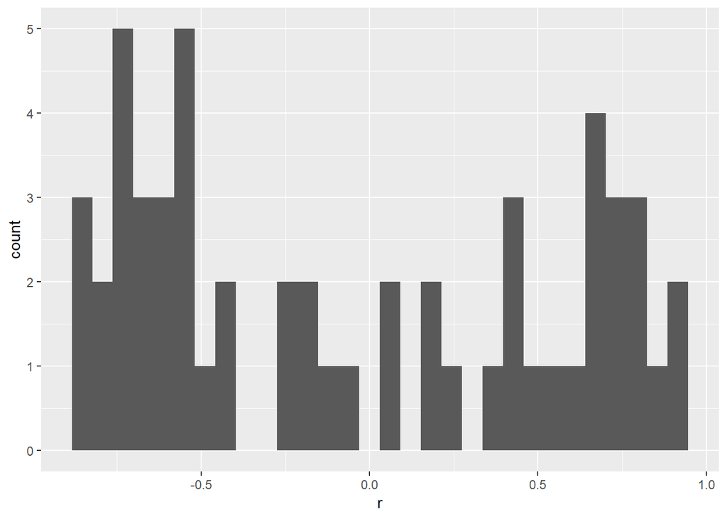

```r
rs %>%
  shave() %>%
  stretch(na.rm = FALSE) %>%
  ggplot(aes(r)) +
    geom_histogram()
```

```r
rs %>%
  focus(mpg:drat, mirror = TRUE) %>%
  rearrange() %>%
  shave(upper = FALSE) %>%
  select(-hp) %>%
  filter(rowname != "drat")
```

| rowname | cyl | mpg | disp | drat |
| --- | --- | --- | --- | --- |
| hp | 0.8298025 | -0.7749843 | 0.7860001 | -0.4425831 |
| cyl | NA | -0.8521620 | 0.9020329 | -0.6999381 |
| mpg | NA | NA | -0.8475514 | 0.6811719 |
| disp | NA | NA | NA | -0.7102139 |

```r
rs %>% fashion()
```

| rowname | mpg | cyl | disp | hp | drat | wt | qsec | vs | am | gear | carb |
| --- | --- | --- | --- | --- | --- | --- | --- | --- | --- | --- | --- |
| mpg |  | -.85 | -.85 | -.77 | .68 | -.87 | .42 | .66 | .60 | .48 | -.55 |
| cyl | -.85 |  | .90 | .83 | -.70 | .78 | -.59 | -.81 | -.52 | -.49 | .53 |
| disp | -.85 | .90 |  | .79 | -.71 | .89 | -.43 | -.71 | -.59 | -.56 | .39 |
| hp | -.77 | .83 | .79 |  | -.44 | .65 | -.71 | -.72 | -.22 | -.12 | .74 |
| drat | .68 | -.70 | -.71 | -.44 |  | -.71 | .09 | .44 | .71 | .70 | -.09 |
| wt | -.87 | .78 | .89 | .65 | -.71 |  | -.17 | -.55 | -.69 | -.58 | .43 |
| qsec | .42 | -.59 | -.43 | -.71 | .09 | -.17 |  | .74 | -.23 | -.21 | -.66 |
| vs | .66 | -.81 | -.71 | -.72 | .44 | -.55 | .74 |  | .17 | .21 | -.57 |
| am | .60 | -.52 | -.59 | -.22 | .71 | -.69 | -.23 | .17 |  | .79 | .06 |
| gear | .48 | -.49 | -.56 | -.12 | .70 | -.58 | -.21 | .21 | .79 |  | .27 |

[output cut: 1 more lines]

```r
rs %>%
  focus(mpg:drat, mirror = TRUE) %>%
  rearrange() %>%
  shave(upper = FALSE) %>%
  select(-hp) %>%
  filter(rowname != "drat") %>%
  fashion()
```

| rowname | cyl | mpg | disp | drat |
| --- | --- | --- | --- | --- |
| hp | .83 | -.77 | .79 | -.44 |
| cyl |  | -.85 | .90 | -.70 |
| mpg |  |  | -.85 | .68 |
| disp |  |  |  | -.71 |

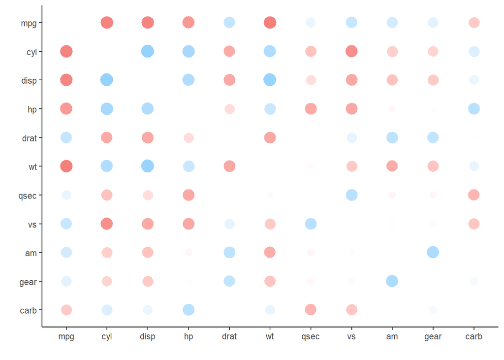

```r
rs %>% rplot()
```

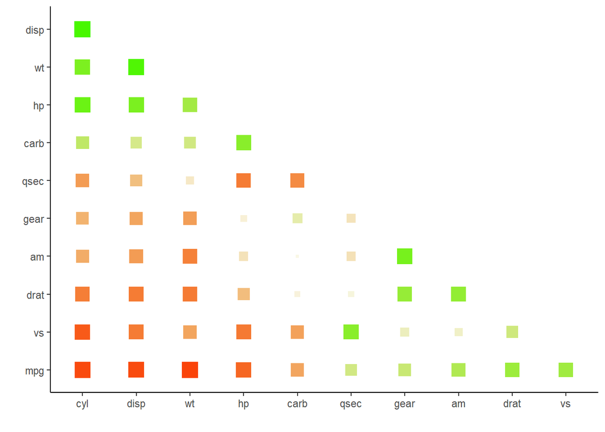

```r
rs %>%
  rearrange(method = "MDS", absolute = FALSE) %>%
  shave() %>%
  rplot(shape = 15, colors = c("red", "green"))
```

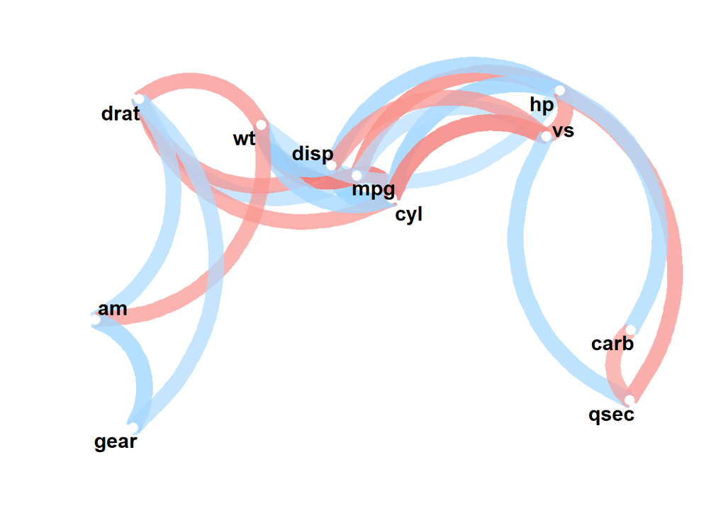

```r
rs %>% network_plot(min_cor = .6)
```